# Case Studies: Context-Dependent miR Behavior Across Cancer Types

Amir (Building on Kevin R. Coombes’ framework)

Original: 2026-01-05; Latest Run: 2026-01-05

# Summary

**What we learned from the pathway analysis (401):** In our previous analysis, we discovered that context-dependency is the *rule*, not the exception. For well-studied miRNAs like let-7a, miR-34a, and miR-362, essentially 100% of genes show context-dependent (mixed positive/negative) correlation across cancer types. Even for miR-21 (the most studied oncomiR), only 14 out of 20,193 genes (0.07%) show consistently negative correlation.

**Goal of this analysis:** Dive deeper into specific case studies to understand *why* certain miR-gene pairs behave differently across cancer types. We will:

1. Examine let-7a (tumor suppressor) - which cancers show strongest negative correlation?
2. Study miR-34a (p53-regulated) - does it behave as a tumor suppressor uniformly?
3. Extend Kevin’s miR-362 example with additional functional analysis
4. Identify cancer types that cluster by miR correlation patterns

**Key Questions:** - Are there cancer-specific miR “signatures” in correlation patterns? - Do known oncogenic contexts show weaker tumor suppressor correlations? - Can we identify tissue-specific miR targets?

# Getting Started

```r
source("00-paths.R")

library(ggplot2)
library(pheatmap)
library(RColorBrewer)
```

```r
load(file.path(paths$mirtcga, "matchedNoGBM.rda"))
load(file.path(paths$mirtcga, "cohortColors.Rda"))

cat("Data loaded:\n")
```

```
## Data loaded:
```

```r
cat("  Genes:", nrow(mRNAdata), "\n")
```

```
##   Genes: 20289
```

```r
cat("  miRs:", nrow(miRdata), "\n")
```

```
##   miRs: 1146
```

```r
cat("  Samples:", ncol(mRNAdata), "\n")
```

```
##   Samples: 8890
```

```r
cat("  Cohorts:", paste(sort(unique(cancerType)), collapse=", "), "\n")
```

```
##   Cohorts: ACC, BLCA, BRCA, CESC, CHOL, COAD, DLBC, ESCA, HNSC, KICH, KIRC, KIRP, LGG, LIHC, LUAD, LUSC, MESO, OV, PAAD, PCPG, PRAD, READ, SARC, SKCM, STAD, TGCT, THCA, THYM, UCEC, UCS, UVM
```

# Utility Functions

I’ll use the same correlation approach as before, but add functions for visualization and comparison across cohorts.

```r
# Compute correlation for one miR with all genes in one cohort
compute_cohort_cor <- function(mir_name, cohort, mRNAdata, miRdata, cancerType) {
  idx <- cancerType == cohort
  if (sum(idx) < 10) return(rep(NA, nrow(mRNAdata)))

  mir_expr <- as.numeric(miRdata[mir_name, idx])
  if (all(mir_expr == 0) || sd(mir_expr) == 0) return(rep(NA, nrow(mRNAdata)))

  cors <- sapply(1:nrow(mRNAdata), function(i) {
    mrna_expr <- as.numeric(mRNAdata[i, idx])
    if (sd(mrna_expr) > 0) {
      cor(mir_expr, mrna_expr, use = "complete.obs")
    } else {
      NA
    }
  })
  names(cors) <- rownames(mRNAdata)
  return(cors)
}

# Compute correlation matrix for one miR across all cohorts
compute_mir_matrix <- function(mir_name, mRNAdata, miRdata, cancerType) {
  cohorts <- sort(unique(as.character(cancerType)))
  result <- matrix(NA, nrow = nrow(mRNAdata), ncol = length(cohorts),
                   dimnames = list(rownames(mRNAdata), cohorts))

  for (ct in cohorts) {
    result[, ct] <- compute_cohort_cor(mir_name, ct, mRNAdata, miRdata, cancerType)
  }
  return(result)
}
```

# Case Study 1: let-7a - The Canonical Tumor Suppressor

Let-7a was one of the first discovered miRNAs and is well-established as a tumor suppressor. It directly targets oncogenes like RAS and HMGA2. If correlation reflects regulation, we should see consistent negative correlation with these targets.

```r
# Find let-7a variants
let7a_mirs <- grep("let-7a", rownames(miRdata), value = TRUE)
cat("Available let-7a variants:\n")
```

```
## Available let-7a variants:
```

```r
print(let7a_mirs)
```

```
## [1] "hsa-let-7a-2-3p" "hsa-let-7a-3p"   "hsa-let-7a-5p"
```

```r
# Use the 5p form (more commonly studied)
let7a <- grep("let-7a-5p", rownames(miRdata), value = TRUE)[1]
cat("\nUsing:", let7a, "\n")
```

```
##
## Using: hsa-let-7a-5p
```

```r
cat("Computing correlations for", let7a, "across all cohorts...\n")
```

```
## Computing correlations for hsa-let-7a-5p across all cohorts...
```

```r
let7a_cors <- compute_mir_matrix(let7a, mRNAdata, miRdata, cancerType)
cat("Done!\n")
```

```
## Done!
```

Let me first look at the distribution of correlations across all cohorts.

```r
# Calculate summary statistics per cohort
let7a_summary <- data.frame(
  cohort = colnames(let7a_cors),
  mean_cor = apply(let7a_cors, 2, mean, na.rm = TRUE),
  median_cor = apply(let7a_cors, 2, median, na.rm = TRUE),
  n_negative = apply(let7a_cors, 2, function(x) sum(x < -0.3, na.rm = TRUE)),
  n_positive = apply(let7a_cors, 2, function(x) sum(x > 0.3, na.rm = TRUE))
)

# Which cohorts have the most negative correlations?
cat("Cohorts ranked by genes with strong negative correlation (r < -0.3):\n")
```

```
## Cohorts ranked by genes with strong negative correlation (r < -0.3):
```

```r
print(let7a_summary[order(-let7a_summary$n_negative), c("cohort", "n_negative", "n_positive")])
```

```
##      cohort n_negative n_positive
## UVM     UVM       2276        806
## THYM   THYM       1929       2782
## PRAD   PRAD       1758        427
## MESO   MESO       1287       1622
## DLBC   DLBC       1194       1298
## LUAD   LUAD        925        538
## UCS     UCS        820        500
## TGCT   TGCT        801       2528
## BLCA   BLCA        542          7
## CHOL   CHOL        496        732
## LUSC   LUSC        488        687
## SARC   SARC        417        238
## HNSC   HNSC        286        285
## COAD   COAD        171          9
## OV       OV        131        140
## READ   READ        114        422
## THCA   THCA         89        174
## UCEC   UCEC         87         84
## ACC     ACC         72         42
## LIHC   LIHC         68         46
## PCPG   PCPG         64         32
## KICH   KICH         50        172
## BRCA   BRCA         47         64
## STAD   STAD         28         62
## SKCM   SKCM         12          4
## KIRP   KIRP          8          9
## CESC   CESC          3          8
## PAAD   PAAD          3         12
## ESCA   ESCA          2          8
## KIRC   KIRC          1          0
## LGG     LGG          0          1
```

This is fascinating! Let’s visualize which cohorts show the strongest tumor suppressor-like behavior (negative correlations).

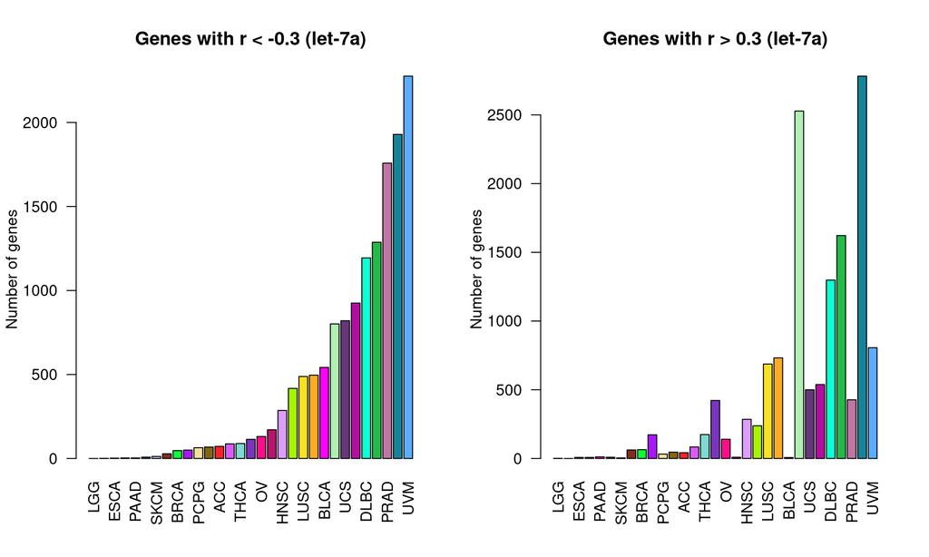

Genes with strong let-7a correlation by cancer type.

```r
# Melt for plotting
let7a_plot <- let7a_summary[order(let7a_summary$n_negative), ]
let7a_plot$cohort <- factor(let7a_plot$cohort, levels = let7a_plot$cohort)

par(mfrow = c(1, 2))
barplot(let7a_plot$n_negative, names.arg = let7a_plot$cohort, las = 2,
        col = cohortColors[as.character(let7a_plot$cohort)],
        main = "Genes with r < -0.3 (let-7a)", ylab = "Number of genes")

barplot(let7a_plot$n_positive, names.arg = let7a_plot$cohort, las = 2,
        col = cohortColors[as.character(let7a_plot$cohort)],
        main = "Genes with r > 0.3 (let-7a)", ylab = "Number of genes")
```

## Known let-7a Targets

Let’s check if known oncogenic targets of let-7a show negative correlation. Classic let-7a targets include RAS genes, HMGA2, and MYC.

```r
# Known let-7a targets
known_targets <- c("KRAS", "NRAS", "HRAS", "HMGA2", "MYC", "LIN28A", "LIN28B", "IGF2BP1", "IGF2BP2")

# Check which are in our data
available_targets <- known_targets[known_targets %in% rownames(let7a_cors)]
cat("Available known targets:", paste(available_targets, collapse = ", "), "\n\n")
```

```
## Available known targets: KRAS, NRAS, HRAS, HMGA2, MYC, LIN28A, LIN28B, IGF2BP1, IGF2BP2
```

```r
# Get their correlations across cohorts
if (length(available_targets) > 0) {
  target_cors <- let7a_cors[available_targets, , drop = FALSE]

  cat("Correlation of known let-7a targets across cohorts:\n")
  print(round(target_cors, 3))

  cat("\nSummary: proportion of cohorts with negative correlation:\n")
  prop_neg <- apply(target_cors, 1, function(x) mean(x < 0, na.rm = TRUE))
  print(round(prop_neg, 2))
}
```

```
## Correlation of known let-7a targets across cohorts:
##            ACC   BLCA   BRCA   CESC   CHOL   COAD   DLBC   ESCA   HNSC   KICH   KIRC   KIRP
## KRAS    -0.025  0.006 -0.050  0.013 -0.133  0.150 -0.045 -0.047  0.068  0.090  0.081  0.069
## NRAS     0.014  0.026 -0.069 -0.079 -0.393  0.034 -0.293 -0.056  0.150  0.089  0.079  0.174
## HRAS     0.010  0.059 -0.100  0.015  0.112 -0.107  0.027  0.012 -0.239 -0.103 -0.011 -0.092
## HMGA2   -0.010 -0.074 -0.091 -0.275 -0.084 -0.149 -0.292 -0.140 -0.193  0.062 -0.076 -0.069
## MYC      0.154 -0.056  0.076 -0.052  0.033  0.021  0.172  0.048  0.033  0.084  0.104 -0.141
## LIN28A   0.083 -0.003 -0.136 -0.306 -0.112 -0.021 -0.239  0.159 -0.020  0.156 -0.031  0.036
## LIN28B  -0.182 -0.004 -0.133 -0.087 -0.065  0.032 -0.502  0.028 -0.122 -0.088  0.009 -0.131
## IGF2BP1 -0.102 -0.060 -0.176 -0.183 -0.282 -0.104 -0.113  0.032 -0.093  0.065 -0.165 -0.025
## IGF2BP2 -0.026 -0.055 -0.121 -0.230 -0.199 -0.102 -0.243 -0.049 -0.151 -0.041 -0.217 -0.136
##            LGG   LIHC   LUAD   LUSC   MESO     OV   PAAD   PCPG   PRAD   READ   SARC   SKCM
## KRAS     0.006  0.198 -0.123 -0.137 -0.196 -0.150  0.049 -0.043  0.060  0.124  0.049 -0.243
## NRAS    -0.020 -0.058  0.055  0.009 -0.344 -0.223  0.056  0.072  0.047  0.003  0.256 -0.234
## HRAS    -0.092 -0.294 -0.194 -0.245  0.350 -0.025 -0.012 -0.115  0.111 -0.218  0.106  0.156
## HMGA2    0.006 -0.111 -0.099 -0.256  0.001 -0.257  0.065  0.074 -0.106 -0.107  0.217 -0.251
## MYC     -0.089  0.014  0.107 -0.140 -0.155  0.169  0.103  0.191  0.169  0.092  0.236 -0.132
## LIN28A  -0.002 -0.145 -0.196 -0.175 -0.016 -0.161 -0.110 -0.154 -0.052 -0.036 -0.066 -0.317
## LIN28B  -0.030 -0.375 -0.197 -0.152  0.074 -0.380 -0.049 -0.121  0.050  0.212 -0.075 -0.404
## IGF2BP1 -0.031 -0.212 -0.226 -0.180 -0.029 -0.296  0.065 -0.066  0.017 -0.018  0.002 -0.250
## IGF2BP2  0.037 -0.109 -0.125 -0.210 -0.279 -0.198  0.090  0.083 -0.307 -0.262  0.143 -0.123
##           STAD   TGCT   THCA   THYM   UCEC    UCS    UVM
## KRAS     0.137 -0.309 -0.006 -0.242 -0.174 -0.104 -0.268
## NRAS     0.161 -0.226 -0.001 -0.187 -0.101 -0.301 -0.262
## HRAS    -0.135 -0.119 -0.199 -0.045  0.146  0.092  0.231
## HMGA2   -0.030 -0.024 -0.089  0.236 -0.243 -0.433 -0.069
## MYC     -0.037  0.235  0.023 -0.334 -0.147  0.089 -0.067
## LIN28A   0.043 -0.317  0.031  0.049 -0.203  0.097 -0.202
## LIN28B  -0.121 -0.329 -0.038 -0.141 -0.103 -0.579 -0.340
## IGF2BP1 -0.026 -0.339 -0.013  0.274 -0.314 -0.381 -0.002
## IGF2BP2  0.059 -0.259  0.038  0.464 -0.408 -0.293 -0.160
##
## Summary: proportion of cohorts with negative correlation:
##    KRAS    NRAS    HRAS   HMGA2     MYC  LIN28A  LIN28B IGF2BP1 IGF2BP2
##    0.55    0.52    0.58    0.77    0.35    0.74    0.81    0.81    0.77
```

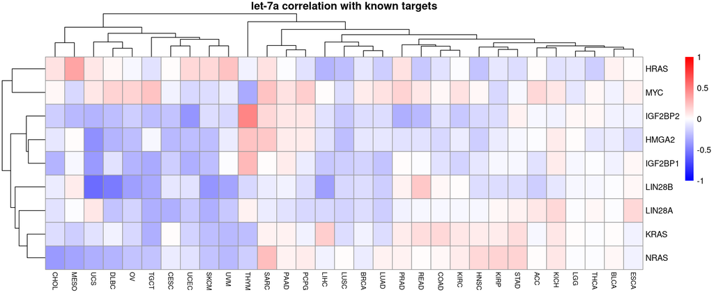

Correlation of known let-7a targets across cancer types.

```r
if (length(available_targets) > 2) {
  # Remove NA rows/cols
  target_cors_clean <- target_cors[, colSums(!is.na(target_cors)) > 0]

  pheatmap(target_cors_clean,
           main = "let-7a correlation with known targets",
           color = colorRampPalette(c("blue", "white", "red"))(100),
           breaks = seq(-1, 1, length.out = 101),
           cluster_rows = TRUE,
           cluster_cols = TRUE,
           fontsize_row = 10,
           fontsize_col = 8)
}
```

Interesting! Even for *known* direct targets of let-7a, the correlation patterns are highly variable across cancer types. This strongly supports Kevin’s thesis that context matters enormously.

# Case Study 2: miR-34a - The p53 Effector

miR-34a is transcriptionally activated by p53 and mediates tumor suppression. Its targets include CDK6, E2F3, and BCL2. Since p53 status varies across cancers, we might expect miR-34a to behave differently depending on p53 functionality.

```r
mir34a <- grep("miR-34a-5p", rownames(miRdata), value = TRUE)[1]
cat("Analyzing:", mir34a, "\n")
```

```
## Analyzing: hsa-miR-34a-5p
```

```r
cat("Computing correlations...\n")
```

```
## Computing correlations...
```

```r
mir34a_cors <- compute_mir_matrix(mir34a, mRNAdata, miRdata, cancerType)
cat("Done!\n")
```

```
## Done!
```

```r
# Summary statistics
mir34a_summary <- data.frame(
  cohort = colnames(mir34a_cors),
  mean_cor = apply(mir34a_cors, 2, mean, na.rm = TRUE),
  n_strong_neg = apply(mir34a_cors, 2, function(x) sum(x < -0.3, na.rm = TRUE)),
  n_strong_pos = apply(mir34a_cors, 2, function(x) sum(x > 0.3, na.rm = TRUE))
)

cat("miR-34a: Cohorts with most strongly correlated genes:\n")
```

```
## miR-34a: Cohorts with most strongly correlated genes:
```

```r
print(mir34a_summary[order(-mir34a_summary$n_strong_neg), ])
```

```
##      cohort      mean_cor n_strong_neg n_strong_pos
## THYM   THYM  0.0271897020         2826         3443
## THCA   THCA -0.0408115872         2386         1213
## STAD   STAD -0.0370009567         2035          731
## TGCT   TGCT -0.0161565975         1937         1792
## KIRC   KIRC -0.0038430999         1932         1654
## LGG     LGG  0.0229340085         1772         2279
## KIRP   KIRP -0.0395587723         1735          942
## SARC   SARC -0.0105478748         1612         1284
## BLCA   BLCA -0.0170227694         1175          647
## PRAD   PRAD  0.0071358135         1045          931
## READ   READ -0.0326280492          804          237
## PCPG   PCPG  0.0059940557          779          841
## UVM     UVM  0.0194685530          751         1037
## DLBC   DLBC  0.0129944629          702          821
## UCEC   UCEC -0.0187692232          672          242
## CHOL   CHOL  0.0027172204          644          714
## UCS     UCS  0.0114429550          517          905
## ACC     ACC  0.0024921822          512          534
## KICH   KICH -0.0069197804          484          202
## PAAD   PAAD -0.0319458021          423          240
## COAD   COAD -0.0341460321          390           74
## HNSC   HNSC  0.0349825785          377          694
## ESCA   ESCA  0.0015201740          368          419
## MESO   MESO -0.0206463243          303          155
## LUAD   LUAD  0.0132261401          179          565
## LIHC   LIHC -0.0122627717          175          210
## OV       OV  0.0082141466           43          143
## CESC   CESC  0.0002760474           28           12
## LUSC   LUSC -0.0006027795           23           26
## SKCM   SKCM -0.0067244032            1           22
## BRCA   BRCA -0.0061704424            0            0
```

## Known miR-34a Targets

```r
# Known miR-34a targets (cell cycle, apoptosis)
mir34a_known <- c("CDK6", "CDK4", "E2F3", "BCL2", "NOTCH1", "MET", "SIRT1", "MYC")
available_34a <- mir34a_known[mir34a_known %in% rownames(mir34a_cors)]

cat("Checking known miR-34a targets:\n")
```

```
## Checking known miR-34a targets:
```

```r
if (length(available_34a) > 0) {
  target34_cors <- mir34a_cors[available_34a, , drop = FALSE]
  print(round(target34_cors, 3))

  cat("\nProportion of cohorts with negative correlation:\n")
  print(round(apply(target34_cors, 1, function(x) mean(x < 0, na.rm = TRUE)), 2))
}
```

```
##           ACC   BLCA   BRCA   CESC   CHOL   COAD   DLBC   ESCA   HNSC   KICH   KIRC   KIRP
## CDK6   -0.333 -0.322 -0.001 -0.180  0.008 -0.049 -0.137 -0.006 -0.318  0.050 -0.049 -0.099
## CDK4    0.072 -0.004 -0.009 -0.040  0.276 -0.094 -0.313  0.026  0.221 -0.253  0.207  0.071
## E2F3    0.032 -0.075 -0.078 -0.119  0.198 -0.147 -0.012  0.209 -0.012  0.068  0.137 -0.097
## BCL2   -0.054 -0.280 -0.114 -0.029  0.312 -0.032  0.100 -0.151  0.213 -0.272  0.066  0.024
## NOTCH1  0.073  0.045 -0.082 -0.154 -0.031  0.072  0.272 -0.172  0.109  0.148  0.017 -0.295
## MET     0.244 -0.004 -0.115 -0.097 -0.420 -0.047 -0.087  0.064 -0.322 -0.155  0.279  0.060
## SIRT1  -0.006 -0.206 -0.156  0.039 -0.326 -0.258  0.040  0.174 -0.103  0.018 -0.160 -0.421
## MYC    -0.240 -0.252 -0.136 -0.181  0.342 -0.089 -0.309 -0.253 -0.130  0.089  0.218  0.143
##           LGG   LIHC   LUAD   LUSC   MESO     OV   PAAD   PCPG   PRAD   READ   SARC   SKCM
## CDK6    0.019  0.180 -0.176 -0.232 -0.208 -0.104 -0.092  0.058  0.121 -0.027  0.375 -0.158
## CDK4   -0.156 -0.083 -0.092 -0.210 -0.275 -0.299 -0.120  0.110  0.108 -0.063  0.441 -0.003
## E2F3   -0.274 -0.098 -0.054 -0.192 -0.311 -0.120 -0.103  0.169 -0.163 -0.021 -0.014 -0.108
## BCL2    0.105 -0.107 -0.132 -0.043 -0.015 -0.056 -0.219 -0.190 -0.056 -0.099 -0.167  0.014
## NOTCH1 -0.467 -0.262  0.000 -0.127  0.179  0.086  0.024  0.123 -0.099  0.094 -0.040 -0.193
## MET     0.467  0.027  0.127  0.032  0.074  0.084  0.111 -0.116 -0.091  0.183  0.158  0.099
## SIRT1  -0.512 -0.126 -0.319  0.013  0.008 -0.161 -0.146  0.233 -0.324 -0.082 -0.164 -0.103
## MYC    -0.531 -0.047 -0.118 -0.031 -0.014 -0.022 -0.107  0.140  0.005 -0.038  0.146 -0.051
##          STAD   TGCT   THCA   THYM   UCEC    UCS    UVM
## CDK6   -0.013  0.215 -0.180 -0.443 -0.198 -0.295  0.319
## CDK4    0.131  0.117  0.370 -0.060 -0.080 -0.139 -0.163
## E2F3    0.018  0.215 -0.042 -0.257 -0.073 -0.191 -0.021
## BCL2   -0.322 -0.226 -0.481  0.316 -0.109  0.025  0.315
## NOTCH1 -0.147  0.164 -0.023  0.059 -0.201  0.116 -0.085
## MET     0.149  0.039  0.491  0.588 -0.040 -0.004  0.208
## SIRT1  -0.217  0.256 -0.221  0.098 -0.193 -0.084  0.108
## MYC    -0.115  0.206 -0.113 -0.058 -0.164  0.009 -0.094
##
## Proportion of cohorts with negative correlation:
##   CDK6   CDK4   E2F3   BCL2 NOTCH1    MET  SIRT1    MYC
##   0.71   0.61   0.74   0.68   0.48   0.39   0.68   0.71
```

# Case Study 3: Deep Dive into miR-362 (Kevin’s Example)

Kevin showed that miR-362 has Cohen’s kappa of 0.120 in PRAD but only 0.003 in SKCM for association with validated targets. Let me explore this more.

```r
mir362 <- grep("miR-362-3p", rownames(miRdata), value = TRUE)[1]
cat("Analyzing:", mir362, "\n")
```

```
## Analyzing: hsa-miR-362-3p
```

```r
mir362_cors <- compute_mir_matrix(mir362, mRNAdata, miRdata, cancerType)
```

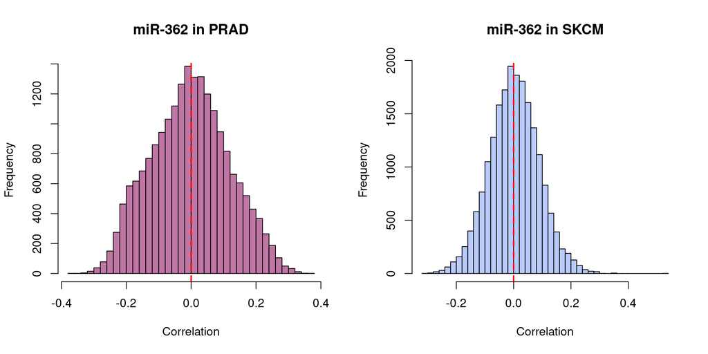

miR-362 correlation patterns in PRAD vs SKCM.

```r
# Compare PRAD and SKCM directly
par(mfrow = c(1, 2))

# PRAD
hist(mir362_cors[, "PRAD"], breaks = 50, main = "miR-362 in PRAD",
     xlab = "Correlation", col = cohortColors["PRAD"])
abline(v = 0, col = "red", lwd = 2, lty = 2)

# SKCM
hist(mir362_cors[, "SKCM"], breaks = 50, main = "miR-362 in SKCM",
     xlab = "Correlation", col = cohortColors["SKCM"])
abline(v = 0, col = "red", lwd = 2, lty = 2)
```

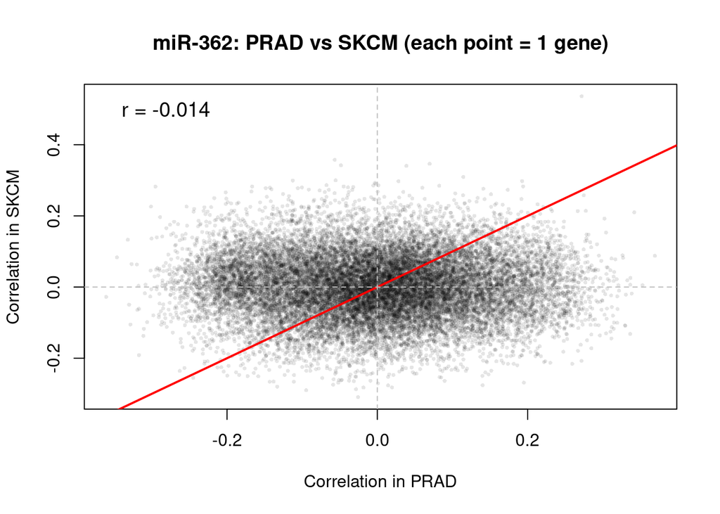

Comparing miR-362 correlations: PRAD vs SKCM.

```r
# Scatter plot comparing the two
plot(mir362_cors[, "PRAD"], mir362_cors[, "SKCM"],
     pch = 16, col = rgb(0, 0, 0, 0.1), cex = 0.5,
     xlab = "Correlation in PRAD", ylab = "Correlation in SKCM",
     main = "miR-362: PRAD vs SKCM (each point = 1 gene)")
abline(0, 1, col = "red", lwd = 2)
abline(h = 0, v = 0, col = "gray", lty = 2)

# Correlation between the correlation profiles
rho <- cor(mir362_cors[, "PRAD"], mir362_cors[, "SKCM"], use = "complete.obs")
legend("topleft", legend = paste("r =", round(rho, 3)), bty = "n", cex = 1.2)
```

The correlation between PRAD and SKCM correlation profiles is only -0.014! This means the same miR has essentially *unrelated* correlation patterns in these two cancer types.

## Genes with Opposite Behavior

Let’s identify genes where miR-362 shows opposite correlation in PRAD vs SKCM.

```r
# Find genes that flip sign
prad_neg_skcm_pos <- which(mir362_cors[, "PRAD"] < -0.2 & mir362_cors[, "SKCM"] > 0.2)
prad_pos_skcm_neg <- which(mir362_cors[, "PRAD"] > 0.2 & mir362_cors[, "SKCM"] < -0.2)

cat("Genes with opposite correlation patterns:\n")
```

```
## Genes with opposite correlation patterns:
```

```r
cat("  Negative in PRAD, Positive in SKCM:", length(prad_neg_skcm_pos), "\n")
```

```
##   Negative in PRAD, Positive in SKCM: 16
```

```r
cat("  Positive in PRAD, Negative in SKCM:", length(prad_pos_skcm_neg), "\n")
```

```
##   Positive in PRAD, Negative in SKCM: 5
```

```r
if (length(prad_neg_skcm_pos) > 0) {
  cat("\nTop genes (negative PRAD, positive SKCM):\n")
  flip_genes <- names(prad_neg_skcm_pos)
  flip_data <- data.frame(
    gene = flip_genes,
    PRAD = mir362_cors[flip_genes, "PRAD"],
    SKCM = mir362_cors[flip_genes, "SKCM"]
  )
  print(head(flip_data[order(flip_data$PRAD - flip_data$SKCM), ], 10))
}
```

```
##
## Top genes (negative PRAD, positive SKCM):
##            gene       PRAD      SKCM
## WDFY1     WDFY1 -0.2951874 0.2822989
## ZC3H7B   ZC3H7B -0.3010475 0.2262190
## FEM1B     FEM1B -0.2538925 0.2261589
## HIPK2     HIPK2 -0.2017527 0.2660746
## ANXA5     ANXA5 -0.2169432 0.2499970
## C5orf22 C5orf22 -0.2435094 0.2197488
## KCNG3     KCNG3 -0.2445354 0.2120882
## HERC1     HERC1 -0.2299996 0.2240853
## USP48     USP48 -0.2009252 0.2485991
## KLRAQ1   KLRAQ1 -0.2211612 0.2246472
```

# Clustering Cancer Types by miR Correlation Patterns

Do cancer types cluster based on how miRNAs correlate with mRNAs? This could reveal tissue-level regulatory patterns.

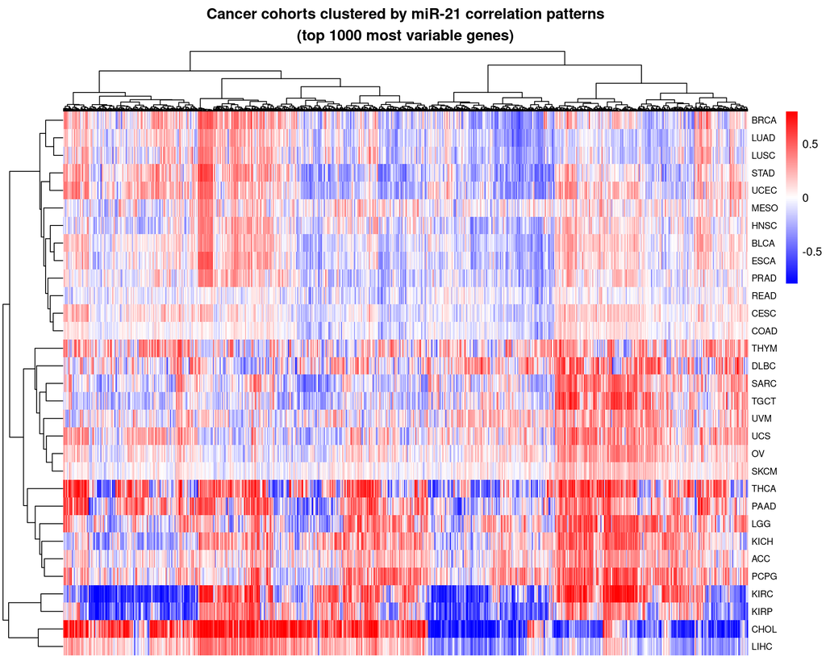

Hierarchical clustering of cancer types by miR-21 correlation patterns.

```r
# Use miR-21 as an example (well-expressed across all cohorts)
mir21 <- grep("miR-21-5p", rownames(miRdata), value = TRUE)[1]
mir21_cors <- compute_mir_matrix(mir21, mRNAdata, miRdata, cancerType)

# Select top 1000 most variable genes for clustering
gene_var <- apply(mir21_cors, 1, var, na.rm = TRUE)
top_genes <- names(sort(gene_var, decreasing = TRUE))[1:1000]
mir21_top <- mir21_cors[top_genes, ]

# Remove cohorts with too many NAs
valid_cohorts <- colSums(!is.na(mir21_top)) > 500
mir21_top <- mir21_top[, valid_cohorts]

# Replace remaining NAs with 0 for clustering
mir21_top[is.na(mir21_top)] <- 0

# Cluster cohorts
pheatmap(t(mir21_top),
         main = "Cancer cohorts clustered by miR-21 correlation patterns\n(top 1000 most variable genes)",
         color = colorRampPalette(c("blue", "white", "red"))(100),
         breaks = seq(-0.8, 0.8, length.out = 101),
         show_colnames = FALSE,
         fontsize_row = 8,
         clustering_method = "ward.D2")
```

# Summary of Findings

These findings provide additional support for Kevin’s central thesis that “correlation is not regulation” and that subgroup structure must be considered in correlation analyses.